## Starting off CRISPR

**11/10/14**

1. Confirm plasmid sequences(**pECA061,060,059,058,057**)
- ALl of the above plasmids were generated by Bryn using the Goldstein plasmid *pDD162*
- Use **GGTGTGAAATACCGCACAGA** to verify sequences
  - Bryn made some primers for checking as well
  - F - oECA486
  - R - oECA484
2. Make sure there is enough co-injection plasmid
- pECA43 - pBCN27-Pmyo-2::GFP::unc-54_3‘UTR
- pECA49 - pDD04neo pmyo2::gfp
3. Inject worms in order to visualize GFP in F1

## While figuring out the above

1. Making new sgRNA plasmid constructs (2 options)
- **A:** Use sgRNA vector from Calarco lab (this is method for coCRISPR)
  - Primers : **oECA547** & **oECA553**
- **B:** Use sgRNA-Cas9 vector from Goldstein lab
  - Forward primer 5’-(N19-25)GTTTTAGAGCTAGAAATAGCAAGT-3’
  - Reverse Primer 5’-CAAGACATCTCGCAATAGG-3’
  - **NOTE** This doesn’t seem to be the recommended protocol on the [NEB Q5 protocol](https://www.neb.com/products/e0554-q5-site-directed-mutagenesis-kit)
  - They suggest using primers with two tail for large insertions. However, Bryn and the Goldstein lab apparently got it working using only one primer with a tail containing the sgRNA

#### Summary of A

Things to include in injection: 1. Cas9 (**pECA51** - Peft-3::cas9-SV40_NLS::tbb-2 3’UTR) 2. co-injection marker (pECA43 or pECA49 (?)) 3. Target sgRNA plasmid (we make) 4. coCRISPR target (*unc-22, ben-1, GFP*)

*constructs 3-4 can be derived from pECA52*

pECA52 - PU6::unc-119_sgRNA

Use Q5 kit to generate these plasmids

**FOR EXAMPLE** (from Bryn)

The below primers were used to generate an sgRNA plasmid that targets GFP (**pECA069**)

The forward primer seems to have the **PAM** site in it which is **NOT** recommended when designing target sequences of the sgRNA. Apparently Mostafa says it is cool because the second G starts the “universal” scaffold RNA

Fwd primer:

oECA548 5’ - GGGCGAGGAGCTGTTCAC **CGG** TTTTAGAGCTAGAAATAGCAAGT - 3’

Reverse primer:

oECA547 5’ - AAACATTTAGATTTGCAATT - 3’

#### Summary of B

1. Cas9 - sgRNA plasmid
- if we go this route we should use coCRISPR sgRNA on the Cas9 plasmid
2. co-injection marker (pECA43 or pECA49 (?))
3. Target sgRNA plasmid (we make)

Figure 2 from [coCRISPR Paper:](http://www.genetics.org/content/197/4/1069.long)

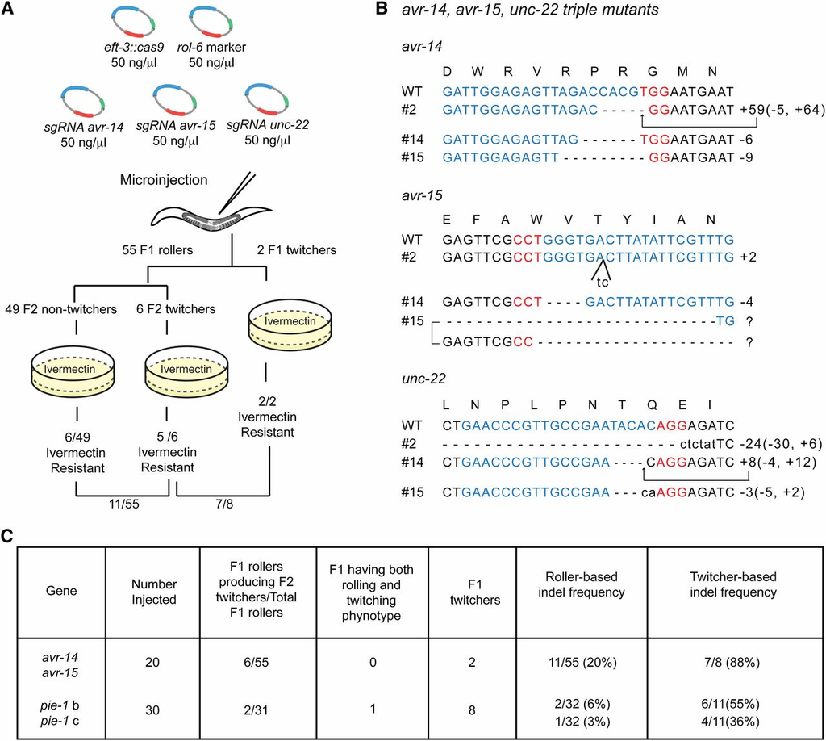